# 贝叶斯第四章

**4.3.3 网格逼近**

网格逼近——探寻后验分布的形状

1.什么是网格逼近？

通过将参数区域划分成有限个网格逼近连续的后验分布，对于每一个参数的取值$p_i$，只需要计算后验概率，即$p_i$对应的先验概率×似然函数值除平均似然，在每一个网格上取一个参数值计算相应的后验概率能够大致逼近后验分布。

2.步骤：

（1）定义网格：你决定用多少个点估计后验概率，然后创建网格上所有参数值的一个列表。

（2）计算网格上每个参数值的先验概率。

（3）计算每个参数值的似然函数。

（4）计算每个参数值的非标准后验概率，通过用似然度乘以先验概率。

（5）通过用每个值除以所有值的和得到标准化后验概率。

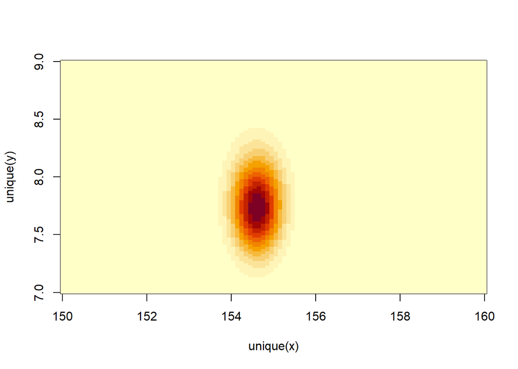

```r
mu.list <- seq( from=150, to=160 , length.out=100 )
sigma.list <- seq( from=7 , to=9 , length.out=100 )
#构造一个数据框，将各参数的各水平完全搭配
post <- expand.grid( mu=mu.list , sigma=sigma.list )
#对每个数据组合算对数似然函数
post$LL <- sapply( 1:nrow(post) , function(i) sum(
  dnorm( d2$height , post$mu[i] , post$sigma[i] , log=TRUE ) ) )
#计算每个参数值的非标准后验概率，这里是对数，所以相乘变为了相加
post$prod <- post$LL + dnorm( post$mu , 178 , 20 , TRUE ) +
  dunif( post$sigma , 0 , 50 , TRUE )
#标准化
post$prob <- exp( post$prod - max(post$prod) )

#可视化
image_xyz( post$mu , post$sigma , post$prob )
```

**4.3.4 从后验分布中抽取样本**

为了更详细地研究这个后验分布，我们将再次从分布中抽取参数值。这就像在第三章中一样，从掷地球的例子的后验分布中抽出p的值。不同的是这里有两个参数，我们需要对它们的组合进行抽样，我们首先随机抽出post$prob中的行号，然后再找到这行中的均值和方差。

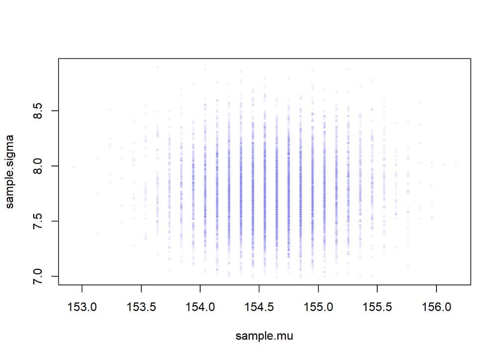

```r
#在所有后验结果中随机抽取10000个样本，重复抽样，按每个参数组合对应的后验概率值进行抽取
sample.rows <- sample( 1:nrow(post) , size=10000 , replace=TRUE ,prob=post$prob )
#抽取该样本对应的均值和方差
sample.mu <- post$mu[ sample.rows ]
sample.sigma <- post$sigma[ sample.rows ]
#可视化：plot(横坐标，纵坐标，点的大小，点的形状，透明度参数)
plot( sample.mu , sample.sigma , cex=0.5 , pch=16 , col=col.alpha(rangi2,0.1) )
```

- 看出从高度数据后验分布抽取的样本，点的密度在中间最高，反映了µ和σ的最合理的组合。

```r
#尾部值
PI( sample.mu )
```

```
##       5%      94%
## 153.9394 155.2525
```

```r
PI( sample.sigma )
```

```
##       5%      94%
## 7.323232 8.272727
```

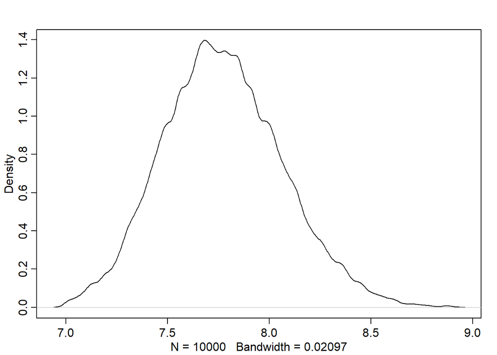

```r
dens( sample.sigma )
```

- $\sigma$分布的右偏性：因为这个参数设定为≥0，它可以无限大，但不能无限小。因此在实际问题中很大可能呈现右偏分布。

**4.3.5 二次逼近**

- 如果仅仅是处理单个参数的后验分布，使用网格逼近就可以解决。但有些现实问题往往存在多个参数，如果计算2个参数100个值的网格，需要$100^2$次。
- 由前面的图形可以观察到，靠近后验概率分布峰值的区域大致符合高斯分布，这意味着我们可以使用高斯分布进行估计。
- 高斯分布的对数像一条抛物线，而抛物线是二次函数，所以该方法称为二次逼近。

该方法有两个步骤：

1）寻找后验分布模式。这通常可以由一些优化算法完成——称为”爬坡”的过程，因为后验分布就像一座山一样，算法不知道峰值在哪，但它已经知道它走过的坡度。

2）一旦找到后验分布的峰值，需要估计峰值附近的曲率，这个曲率用来计算整个后验分布的二次逼近。

```r
#选出成年人数据
library(rethinking)
data(Howell1)
d <- Howell1
d2 <- d[ d$age >= 18 , ]
#将数据存入alist
#alist允许你做一个任意的R对象的集合,但不会执行代码，list会执行。所以当定义一个公式的列表时，你应该使用alist，这样代码就不会被执行。当你定义一个参数起始值的列表时，你应该使用list，这样像mean(d2$height)这样的代码就会被视为一个数字值。
flist <- alist(height ~ dnorm( mu , sigma ),
               mu ~ dnorm( 178 , 20 ) ,
               sigma ~ dunif( 0 , 50 )
               )
#二次逼近，这里没有设置初始值，他是随机的
m4.1 <- quap( flist , data=d2 )
precis( m4.1 )
```

```
##             mean        sd       5.5%      94.5%
## mu    154.607122 0.4120137 153.948645 155.265600
## sigma   7.731691 0.2914197   7.265946   8.197436
```

```r
#设置初始值
start <- list(mu=mean(d2$height),
              sigma=sd(d2$height))
mm4.1 <- quap( flist , data=d2 , start=start )
precis( mm4.1 )
```

```
##             mean        sd       5.5%      94.5%
## mu    154.607024 0.4119947 153.948576 155.265471
## sigma   7.731333 0.2913860   7.265642   8.197024
```

这些结果为每个参数的边际分布提供了高斯近似值。同时展示了89%兼容区间（compatibility interval)的边界。

前面给出的$\mu$的数据所包含的有用信息是很少的，因为它的标准差太大，接下来我们缩小$\mu$的标准差，让他能包含更大的信息量。

```r
m4.2 <- quap(
  alist(height ~ dnorm( mu , sigma ) ,
        mu ~ dnorm( 178 , 0.1 ) ,
        sigma ~ dunif( 0 , 50 )
        ) , data=d2 )

precis( m4.2 )
```

```
##            mean        sd      5.5%     94.5%
## mu    177.86375 0.1002354 177.70356 178.02395
## sigma  24.51757 0.9289237  23.03297  26.00217
```

这里注意到，与前面相比，对µ的后验估计几乎没有脱离先验信息。先验是非常集中在178附近。但是也要注意，σ的估计值变化很大，尽管我们根本没有改变它的先验信息。一旦统计模型确定平均值在178附近–那么就必须以这个事实为条件来估计σ。这导致了对σ的不同后验结果，尽管我们改变的只是关于$\mu$的先验信息。

**4.3.6 从二次逼近结果中抽样** 上面解释了如何使用quap来获得后验的二次近似。但如何从二次近似后验分布中获得样本呢？

1.方差-协方差矩阵：

对一个具有多个参数维度的后验分布的二次近似–µ和σ各贡献一个维度–可以看作一个多维的高斯分布。引入多维高斯分布，就不仅需要均值和方差数据，还需要协方差数据。

```r
#方差—协方差矩阵
vcov(m4.1)
```

```
##                mu       sigma
## mu    0.169755311 0.000220241
## sigma 0.000220241 0.084925455
```

```r
#mu和sigma的方差，开根号能得到precis中sd的结果
diag( vcov( m4.1 ) )
```

```
##         mu      sigma
## 0.16975531 0.08492546
```

```r
#协方差矩阵，自身相关系数为1，和另外一个参数的相关系数接近0，验证了mu和sigma独立，但实际中很罕见。
cov2cor( vcov( m4.1 ) )
```

```
##                mu       sigma
## mu    1.000000000 0.001834288
## sigma 0.001834288 1.000000000
```

2.在多维高斯分布中抽取向量：

```r
#在二次逼近得到的数据m4.1中抽取10000个样本
library(rethinking)
post <- extract.samples( m4.1 , n=10000 )

#上述操作将得到10000行两列的数据，均值列的均值方差&方差列的均值方差会和二次逼近的结果很接近
precis(post)
```

```
##             mean        sd       5.5%      94.5%    histogram
## mu    154.609724 0.4086193 153.952059 155.256364      ▁▁▅▇▂▁▁
## sigma   7.724619 0.2867175   7.262958   8.177314 ▁▁▁▂▅▇▇▃▁▁▁▁
```

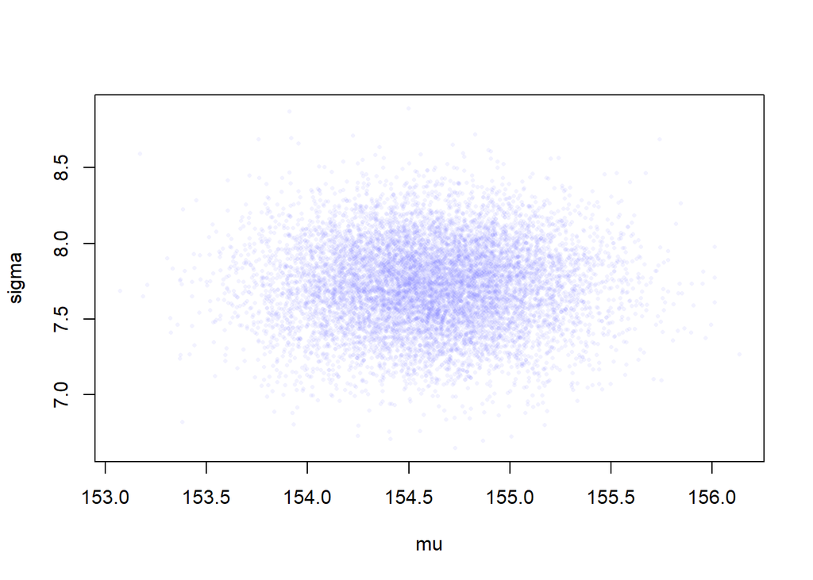

```r
plot(post,cex=0.5 , pch=16 , col=col.alpha(rangi2,0.1))
```

```r
#和之前网格逼近的图进行比较
```

**更进一步：**前面我们只用到了简单抽样extract.samples，还可以用从多维高斯分布中抽样的代码语句mvrnorm：

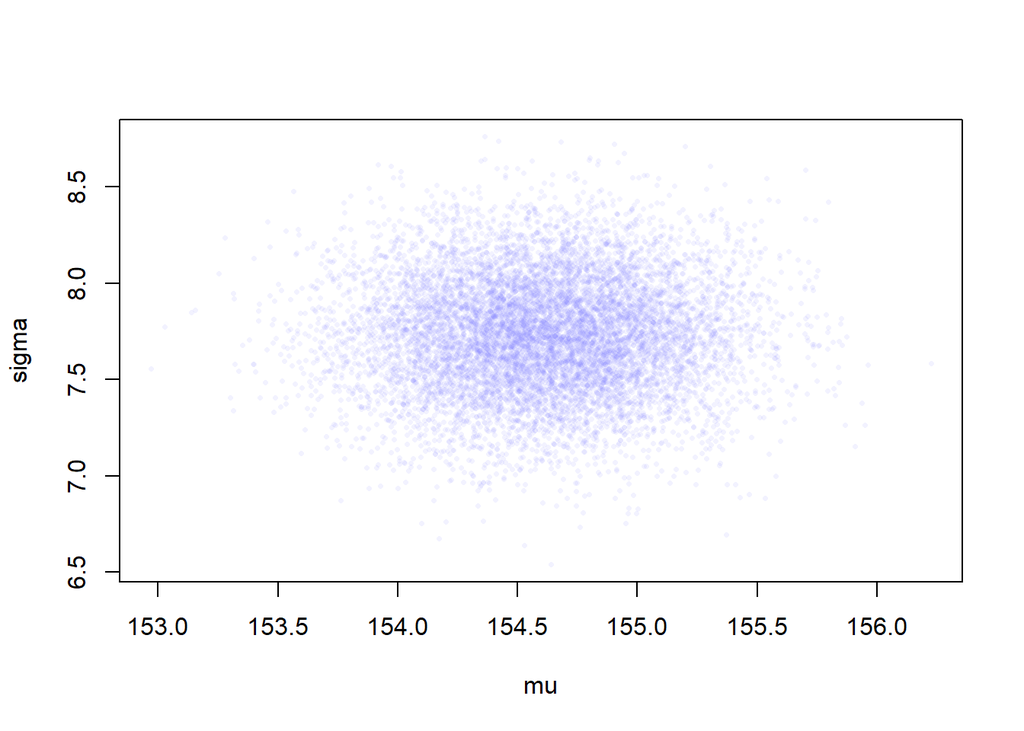

```r
library(MASS)
post_1 <- mvrnorm( n=10000 , mu=coef(m4.1) , Sigma=vcov(m4.1) )
plot(post_1,cex=0.5 , pch=16 , col=col.alpha(rangi2,0.1))
```